Back to home page

# Airbnb Market Analysis - Part II

The idea of this notebook is to give you some insights of airbnb San Francisco market as well as the factors that can affect a host's revenue. **Part II** will mainly focus on the occupancy part.

`monthly income of a host = price * monthly occupancy`

## About occupancy label

Currently there are no publicly available and verifiable sources to precisely identify the occupancy rate of Airbnb units. However, there are several indicators combined together can give a reasonable estimate of the occupancy.

- **calendar**. The next 30 days of booking calendar on each listing is an approximation of the next 30 days occupancy. However, when a day is blocked for booking, the calendar data does not provide any information whether it is booked by a guest or blocked by the host.
- **reviews rate**. Airbnb guests may leave a review after their stay, and these can be used as an indicator of airbnb activity. According to Inside Airbnb, the overall review rate is around 50% for the number of guests making a booking who leave a review.
- **Average length of stay per guest** is 4.2 days, according to "[Overview of the Airbnb Community in San Francisco](https://www.airbnbcitizen.com/wp-content/uploads/sites/6/2017/03/SFEconomicImpactMiniReport.pdf)" by airbnb.

I used available_30 column as my target, which means the total number of days available for booking for the next 30 days at that scraping day. To make sure it is real guest booking calendar (not host blocking), I need such listing to prove itself that it had received "enough" reviews in the last 30 days, given its actual booking situation. In other words, a hot listing today, is supposed to have a lot of reviews last month. But how many is enough? There is no principled way to define it, here is what I did:

The number of reviews left in the past 30 days should be greater or equal to the anticipated number of guests that could leave reviews in the next 30 days if the calendar information is 'real'. This is a conservative estimate, since with time passing by, the real booked days could be higher than the total number of available days at that scraped day.

Sudo code:

- If number of reviews in the last month >= (30 - available_30) / 4.2 days (average stay) * 0.5 (reviews rate) is True => kept in my training set; removed such listing if otherwise.
- If (30 - available_30) / 4.2 * 0.5 < 1, i.e. available_30 > 21 => look into last 2 month => number of reviews in the last 2 month >= (30 - available_30) / 4.2 * 0.5 => True to keep, False to remove.
- If (30 - available_30) / 4.2 * 0.5 < 0.5, i.e. available_30 > 25 => look into last 3 month; so on and so forth.
- If available_30 == 30 => we don't need any past reviews, because the host did not block any day, every day is available for booking.

Here is the data after going through all the process above:

```python
import pandas as pd
import numpy as np
import function as F
import matplotlib.pyplot as plt
import seaborn as sns
import json
from wordcloud import WordCloud, STOPWORDS
from nltk.corpus import stopwords
from nltk.tokenize import RegexpTokenizer
from nltk import WordNetLemmatizer

%config InlineBackend.figure_format = 'retina'
%matplotlib inline
plt.style.use('ggplot')
```

```python
listings = pd.read_csv('data/listings/listings.csv')
```

```python
listings = listings[listings.bedrooms <= 7]
listings = listings[listings.neighbourhood_cleansed!='Presidio'] # sample from this zone is too small
mask = (((listings.price>=1000)&(listings.bedrooms==1))|(listings.price>=3000)) #Remove abnormal price data, here price is rate per night
listings = listings[~mask]
```

```python
listings.shape
```

```
(41568, 40)
```

```python
listings['occupancy_30'] = 30 - listings.availability_30 # label
```

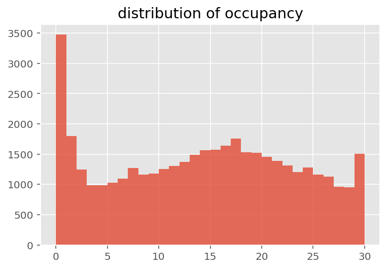

```python
ax = listings.occupancy_30.hist(bins=30, alpha=0.8)
ax.set_title('distribution of occupancy');
```

### Bedrooms

```python
listings.groupby(['bedrooms'])['occupancy_30'].mean()
```

```
bedrooms
1.0    13.854339
2.0    13.896784
3.0    13.070912
4.0    12.970679
5.0    11.845588
6.0    11.000000
7.0     7.352941
Name: occupancy_30, dtype: float64
```

More bedrooms are harder to rent out than less bedroom.

### Room type

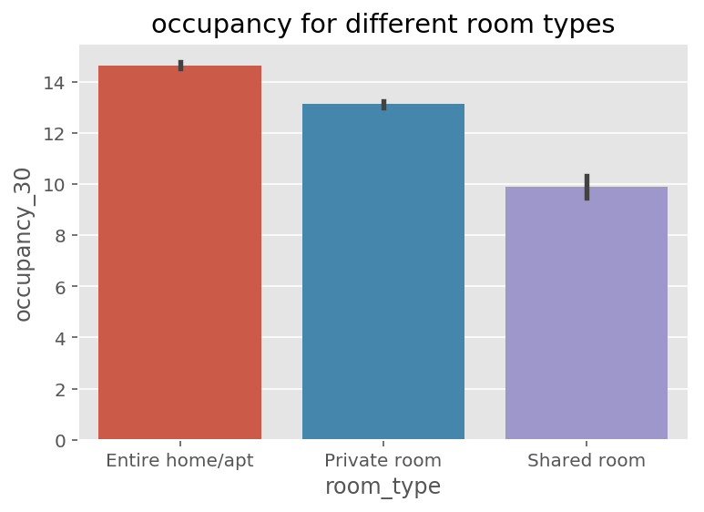

```python
ax = sns.barplot(x="room_type", y="occupancy_30", data=listings, )
ax.set_title('occupancy for different room types');
```

Entire home/apt are the most popular, and shared rooms are the least desirable in terms of occupancy.

### Neighbourhood

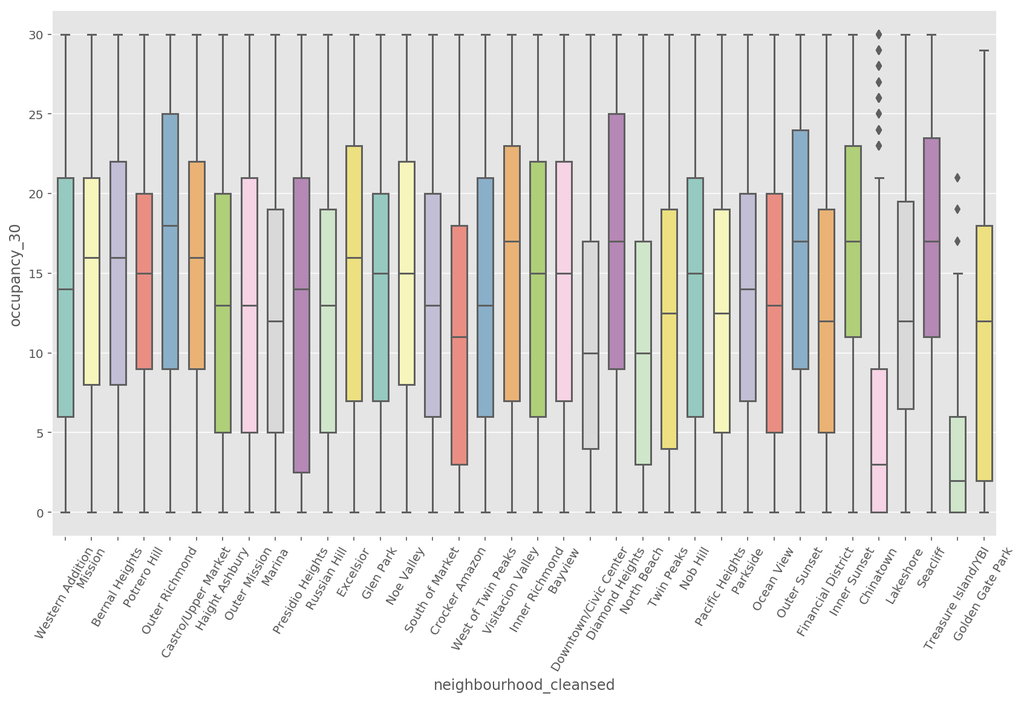

```python
plt.figure(figsize=(14,8))
ax = sns.boxplot(x="neighbourhood_cleansed", y="occupancy_30", data=listings, palette="Set3", width=0.6)
ax.set_xticklabels(ax.get_xticklabels(),rotation=60);
```

Surprisingly, most neighbourhoods do not make a big difference.

Relatively low occupancy neighbourhoods are

- Crocker Amazon
- Chinatown
- Treasure island
- Golden Gate Park

### Seasonal effect

```python
listings.last_scraped = pd.to_datetime(listings.last_scraped)
```

```python
listings['month'] = listings.last_scraped.dt.month
```

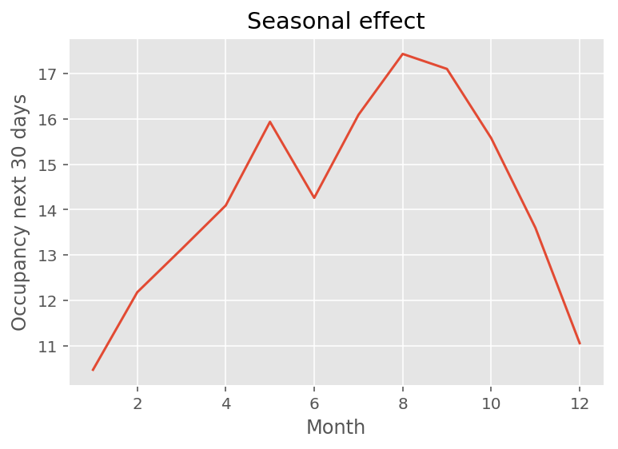

```python
month_effect = listings.groupby('month')['occupancy_30'].mean()
plt.plot(month_effect)
plt.title('Seasonal effect')
plt.xlabel('Month')
plt.ylabel('Occupancy next 30 days');
```

We can see that there is much more demand in summer than any other seasons. (seansonal effect is not yet included in my model)

### host's listings count

```python
listings.calculated_host_listings_count.describe()
```

```
count    41568.000000
mean         3.294120
std          7.367449
min          1.000000
25%          1.000000
50%          1.000000
75%          3.000000
max         69.000000
Name: calculated_host_listings_count, dtype: float64
```

The maximum number of listings belongs to a host is 69. And average number of listings per host is 3.3.

```python
listings['listings_number'] = pd.cut(listings.calculated_host_listings_count,bins=[0,1,3,5,20,100])
```

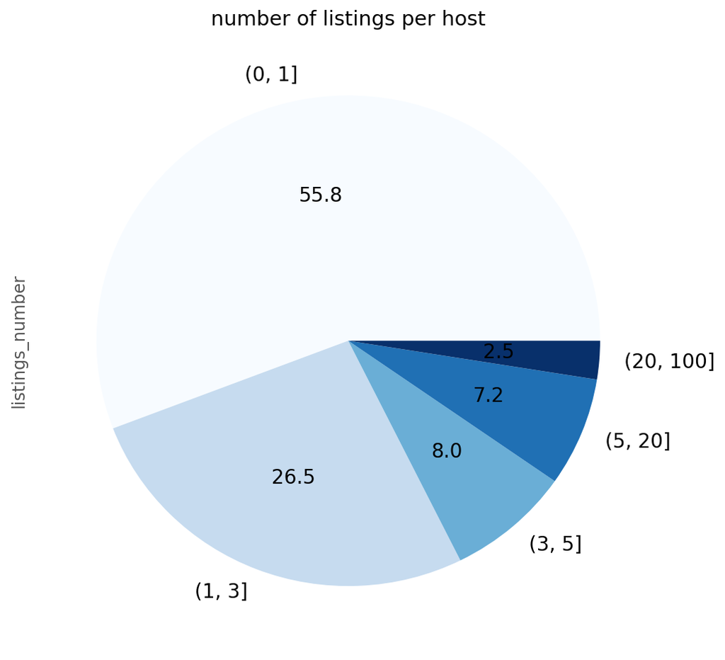

```python
nb_listings = listings.listings_number.value_counts()
nb_listings.plot.pie(colormap = 'Blues', figsize=(8,8),
               fontsize = 14, autopct = '%.1f',
               title = 'number of listings per host');
```

```python
listings['listings_number'].value_counts().sort_index()
```

```
(0, 1]       23202
(1, 3]       11027
(3, 5]        3307
(5, 20]       2980
(20, 100]     1052
Name: listings_number, dtype: int64
```

Most host has 1 listing, however some hosts have a very large number of listings. I guess they are some short-term rental management companie like [Pillow](https://www.pillow.com/).

```python
listings['price per bedrooms'] = listings.price/listings.bedrooms
listings['income per bedroom month'] = listings['price per bedrooms'] * listings['occupancy_30']
listings.groupby('listings_number').mean()[['review_scores_rating','number_of_reviews','instant_bookable','price per bedrooms','occupancy_30','income per bedroom month']]
```

| listings_number | review_scores_rating | number_of_reviews | instant_bookable | price per bedrooms | occupancy_30 | income per bedroom month |
| --- | --- | --- | --- | --- | --- | --- |
| (0, 1] | 94.626412 | 58.861305 | 0.280407 | 157.502534 | 14.487415 | 2063.019362 |
| (1, 3] | 94.693661 | 62.825247 | 0.329101 | 134.548297 | 13.791784 | 1685.316280 |
| (3, 5] | 93.004838 | 65.933172 | 0.513759 | 110.076594 | 12.922891 | 1319.916422 |
| (5, 20] | 90.186577 | 52.927517 | 0.440604 | 124.001518 | 10.824497 | 1178.276722 |
| (20, 100] | 89.528517 | 47.441065 | 0.560837 | 102.044202 | 9.596958 | 878.494297 |

According Airbnb, **Instant Bookable Listings** don't require approval from the host before they can be booked. If a host controls more listings, (those listings are more like a hotel for me), the instant bookable proportion tends to be higher for those cases. But operating like a hotel or using a service company does not necessarily lead to higher review score or income per bedroom.

### Reviews

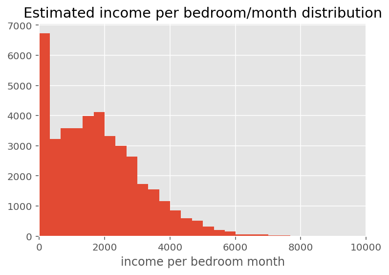

```python
ax = listings['income per bedroom month'].hist(bins=50)
ax.set_xlim(0,10000)
ax.set_xlabel('income per bedroom month')
ax.set_title('Estimated income per bedroom/month distribution');
```

```python
listings['income per bedroom month'].describe()
```

```
count    41568.000000
mean      1810.300281
std       1394.979484
min          0.000000
25%        714.000000
50%       1650.000000
75%       2625.000000
max      16698.000000
Name: income per bedroom month, dtype: float64
```

[figure not shown]

```python
ax = sns.regplot(x="income per bedroom month", y="reviews_per_month", data=listings, scatter_kws={'alpha':0.002})
ax.set_ylim(-5, 20)
ax.set_xlim(0,8000)
ax.set_title('income per bedroom vs number of reviews per month');
```

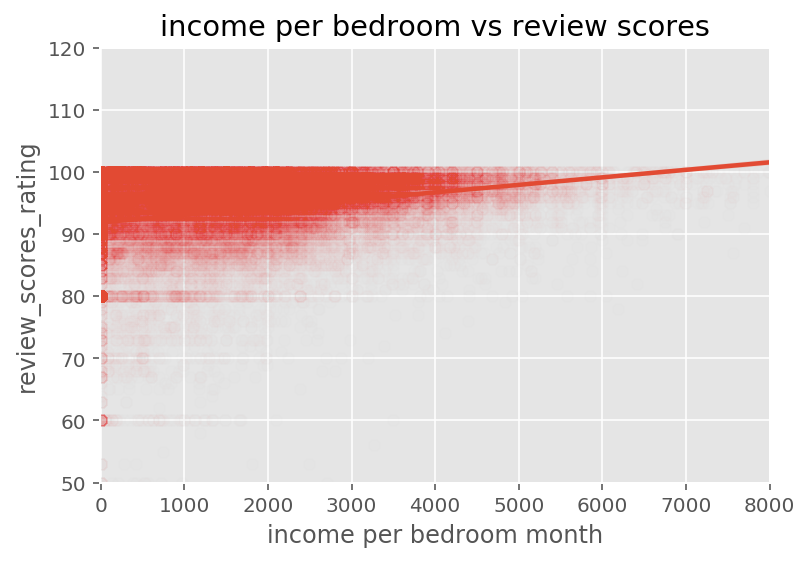

```python
ax = sns.regplot(x="income per bedroom month", y="review_scores_rating", data=listings, scatter_kws={'alpha':0.002})
ax.set_ylim(50, 120)
ax.set_xlim(-10,8000)
ax.set_title('income per bedroom vs review scores');
```

Let's look at how the top hosts describe their houses by the key-words.

```python
top1000listings = listings.sort_values(by=['occupancy_30','income per bedroom month'], ascending=False).head(1000)
```

```python
tokenizer = RegexpTokenizer(r"[\w']+")
stop_set = set(stopwords.words('english') + ['room', 'bedroom','San','Francisco', 'apartment', 'Guest','guest'])
lemmatizer = WordNetLemmatizer()
def tokenize(text):
    tokens = tokenizer.tokenize(text)
    lemm = [lemmatizer.lemmatize(token) for token in tokens if token not in stop_set]
    return lemm
```

### Description column

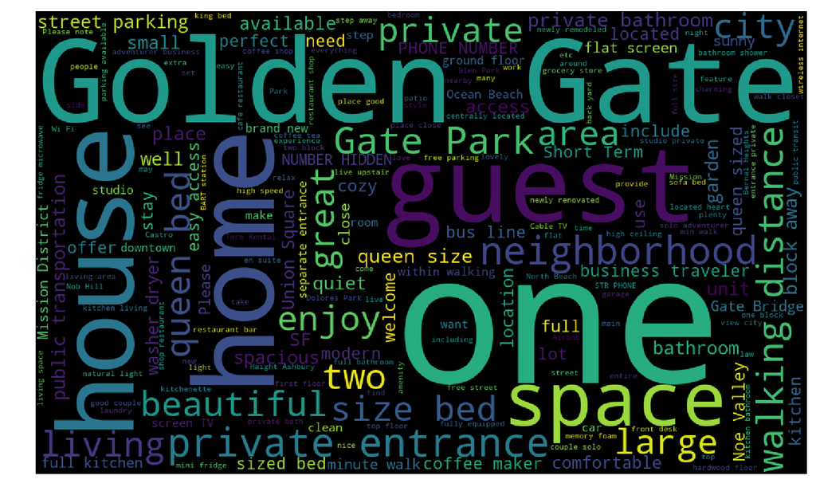

```python
topwords = top1000listings.description.apply(lambda x: tokenize(x))
clouds = ' '.join([word for words in topwords for word in words])
wordcloud = WordCloud(width = 1000, height = 600).generate(clouds)
plt.figure(figsize=(14,8))
plt.imshow(wordcloud)
plt.axis("off")
plt.show()
```

```python
top1000listings.description.iloc[0]
```

```
"Classic San Francisco Victorian charm combined with brand new modern amenities ensures your stay with us is as comfortable as it is memorable. Located right in the heart of Hayes Valley with a private, sunny deck: a perfect relaxing oasis. This is the top floor flat in a quintessential San Francisc…
```

### Transit column

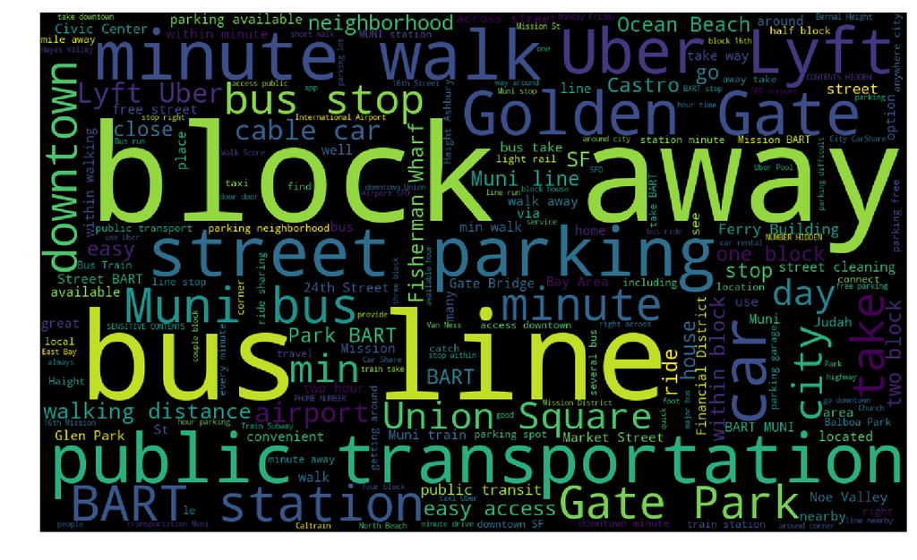

```python
topwords = top1000listings.transit.dropna().apply(lambda x: tokenize(x))
clouds = ' '.join([word for words in topwords for word in words])
wordcloud = WordCloud(width = 1000, height = 600).generate(clouds)
plt.figure(figsize=(14,8))
plt.imshow(wordcloud)
plt.axis("off")
plt.show()
```

```python
top1000listings.transit.iloc[1]
```

```
'We are close to several bus lines, but Uber and Lyft are only about a 2 minute wait on average.'
```

### Access column

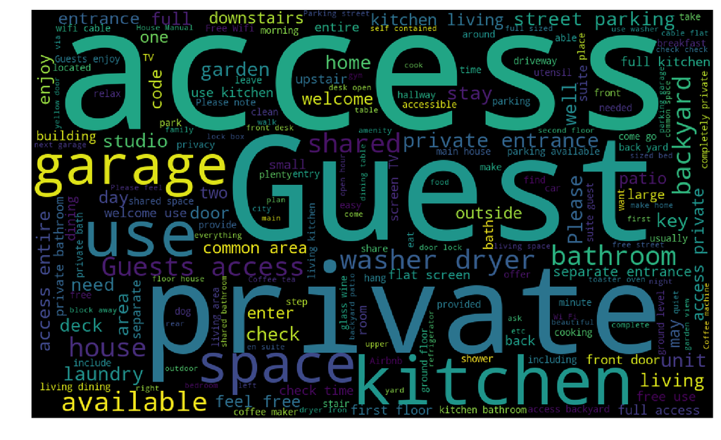

```python
topwords = top1000listings.access.dropna().apply(lambda x: tokenize(x))
clouds = ' '.join([word for words in topwords for word in words])
wordcloud = WordCloud(width = 1000, height = 600).generate(clouds)
plt.figure(figsize=(14,8))
plt.imshow(wordcloud)
plt.axis("off")
plt.show()
```

```python
top1000listings.access.iloc[0]
```

```
"You'll have access to the entire unit and private patio."
```